# 土地利用、生物多样性和环境公平

康杰锋

## **引言**

本文主要是关于土地利用、社会经济因子和生物多样性的关系，要讨论的主要问题是土地利用的影响和环境公平。

在先行研究中，除了土地利用等景观要素与生物多样性的关系，还有很多研究聚焦社会经济要素和生物多样性的关系。后者的结果表明，在很多城市中，存在”luxury effect”，其实就是环境不平等在生物多样性方面的体现：收入越高的居住区，往往生物多样性也越高。但是这个结果可能因城市设计、人们的居住选择、文化而有所不同。本文综合了**景观要素和社会经济要素，探究城市生物多样性的成因或后果，且比较了不同类群（乔木和灌木）的多种多样性指标。**

本研究的响应变量为各种生物多样性指标，包括：乔木的abundance、richness、Shannon指数，灌木的abundance、richness、Shannon指数，乔木灌木合起来的richness。

解释变量包括：（1）景观变量，为样地中各类土地覆盖的百分比，包括居住用地、交通用地、农业用地、公园、公共机构等等；（2）社会变量，为人口结构，包括0-14岁、15-64岁、65岁以上、75岁以上、85岁以上人口占比；（3）经济变量，采用了地价。

我先用斯皮尔曼（和之前不同；之前用的是皮尔森）相关简单看了各个响应变量和各解释变量的关系，然后对每一个相应变量～解释变量组都构建了GLM模型。至于之前的”最佳模型”，在本次分析中删除了，因为变量数量不多，加之筛选最佳模型的话结果太复杂，因此感觉没有必要进行该步骤。**注意：要如何理解相关分析和GLM模型之间的关系 - 相关性分析可以看作基础分析，因为它每次只考虑一个变量，而GLM则考虑了诸多变量；此外，两者结合来看，如果效应一致的话，可以看作一种相互印证。**

## 描述性统计

展示一部分原始数据，以便对下文的分析有点基础直观的理解。原始数据中的主要内容：qua_id - 样地编号，总共有174个样地；各个样地的生物多样性数值，如tree_abundance、tree_richness等，这些是分析中的因变量；自变量，包含3类：第一类各个样地中各类土地利用的占比 - 例如park是调查样地中公园用地的比例，第二类是各年龄层人口占比 - 例如pop65_74_prop是65-74岁的人口所占的比例，第三类是用于指代经济水平的土地价格变量。完整的原始数据见文件：qua_bd_var.csv。

| qua_id | tree_abundance | tree_richness | tree_shannon | shrub_abundance | shrub_richness | shrub_shannon | low_resi | transport | other | mid_high_resi | com_ind | park | mesh_code | shicode | pop0_14 | pop15_64 | pop65over | pop75over | pop85over | pop_src | popt | pop65_74 | pop0_14_prop | pop15_64_prop | pop65_74_prop | pop75over_prop | price |
| --- | --- | --- | --- | --- | --- | --- | --- | --- | --- | --- | --- | --- | --- | --- | --- | --- | --- | --- | --- | --- | --- | --- | --- | --- | --- | --- | --- |
| 6 | 7 | 5 | 1.3862944 | 6.7100 | 6 | 1.5395195 | 0.3873106 | 0.6106825 | 0.0000000 | 0.0000000 | 0.0000000 | 0.0000000 | 5235358208 | 26100 | 8.5917 | 31.6820 | 26.3122 | 10.7397 | 3.2219 | in_mesh | 66.5859 | -15.5725 | 0.1290318 | 0.4758064 | -0.2338708 | 0.1612909 | 168.0185 |
| 7 | 0 | 0 | 0.0000000 | 1.1600 | 4 | 1.0344132 | 0.6493551 | 0.3499658 | 0.0000000 | 0.0000000 | 0.0000000 | 0.0000000 | 5235363251 | 26100 | 18.1532 | 81.2198 | 23.1610 | 11.1110 | 2.0344 | in_mesh | 122.5340 | -12.0500 | 0.1481483 | 0.6628348 | -0.0983401 | 0.0906769 | 212.2386 |
| 15 | 31 | 10 | 1.9529143 | 17.3000 | 7 | 1.3000936 | 0.2038574 | 0.0305681 | 0.7648937 | 0.0000000 | 0.0000000 | 0.0000000 | 5235464018 | 26100 | 7.4736 | 36.6387 | 19.5042 | 10.2078 | 2.9165 | in_mesh | 63.6165 | -9.2964 | 0.1174790 | 0.5759308 | -0.1461319 | 0.1604584 | 413.0508 |
| 16 | 0 | 0 | 0.0000000 | 5.0400 | 6 | 1.5038732 | 0.1070731 | 0.0000000 | 0.0000000 | 0.8922642 | 0.0000000 | 0.0000000 | 5235366418 | 26100 | 5.9485 | 29.4637 | 9.2946 | 3.7178 | 1.1153 | in_mesh | 44.7068 | -5.5768 | 0.1330558 | 0.6590429 | -0.1247417 | 0.0831596 | 187.3397 |
| 17 | 6 | 4 | 1.3296613 | 7.7000 | 2 | 0.6788267 | 0.0000000 | 0.0407420 | 0.0000000 | 0.9592916 | 0.0000000 | 0.0000000 | 5235364158 | 26100 | 32.4515 | 111.1167 | 48.0826 | 22.2573 | 5.7767 | in_mesh | 191.6508 | -25.8253 | 0.1693262 | 0.5797873 | -0.1347519 | 0.1161347 | 222.6687 |
| 18 | 5 | 3 | 1.0549202 | 11.3000 | 3 | 0.8349222 | 0.0063270 | 0.9537780 | 0.0000000 | 0.0392241 | 0.0000000 | 0.0000000 | 5235467362 | 26100 | 7.1447 | 32.5740 | 12.0208 | 6.1742 | 1.8925 | in_mesh | 51.7395 | -5.8466 | 0.1380899 | 0.6295770 | -0.1130007 | 0.1193324 | 273.8865 |
| 21 | 8 | 8 | 2.0794415 | 1.7800 | 8 | 1.8250710 | 0.4228181 | 0.1657476 | 0.4107703 | 0.0000000 | 0.0000000 | 0.0000000 | 5235366433 | 26100 | 17.9984 | 85.9169 | 33.7895 | 16.4702 | 5.0939 | in_mesh | 137.7048 | -17.3193 | 0.1307028 | 0.6239209 | -0.1257712 | 0.1196051 | 195.1197 |
| 22 | 29 | 7 | 1.1578638 | 2.0430 | 8 | 1.8946898 | 0.5582194 | 0.4411059 | 0.0000000 | 0.0000000 | 0.0000000 | 0.0000000 | 5235464205 | 26100 | 8.8936 | 82.7675 | 29.8365 | 14.2010 | 5.0206 | in_mesh | 121.4976 | -15.6355 | 0.0731998 | 0.6812274 | -0.1286898 | 0.1168830 | 373.8152 |
| 24 | 17 | 12 | 2.3639211 | 13.8525 | 9 | 1.5543467 | 0.2973664 | 0.2757241 | 0.1144663 | 0.0000000 | 0.3117798 | 0.0000000 | 5235364584 | 26100 | 15.6998 | 58.3134 | 36.6328 | 24.9701 | 8.8218 | in_mesh | 110.6460 | -11.6627 | 0.1418922 | 0.5270267 | -0.1054055 | 0.2256756 | 187.9167 |
| 25 | 12 | 5 | 1.5171064 | 0.0000 | 0 | 0.0000000 | 0.8001414 | 0.0000000 | 0.0000000 | 0.1991802 | 0.0000000 | 0.0000000 | 5235466142 | 26100 | 17.9134 | 73.5123 | 24.9078 | 11.9180 | 4.0729 | in_mesh | 116.3335 | -12.9898 | 0.1539832 | 0.6319100 | -0.1116600 | 0.1024468 | 378.7583 |
| 36 | 6 | 1 | 0.0000000 | 2.7004 | 2 | 0.6027752 | 0.0000000 | 0.9245546 | 0.0000000 | 0.0000000 | 0.0000000 | 0.0747928 | 5235368671 | 26100 | 3.0616 | 21.1522 | 11.1347 | 6.3154 | 2.0890 | in_mesh | 35.3485 | -4.8193 | 0.0866119 | 0.5983903 | -0.1363368 | 0.1786610 | 149.4908 |
| 37 | 0 | 0 | 0.0000000 | 1.1425 | 5 | 1.4317529 | 0.0000000 | 0.0000000 | 0.0000000 | 0.0000000 | 0.0000000 | 0.9993071 | 5235353971 | 26100 | 0.0000 | 0.2181 | 0.0078 | 0.0000 | 0.0000 | near_mesh | 0.2259 | -0.0078 | 0.0000000 | 0.9654714 | -0.0345286 | 0.0000000 | 223.6760 |
| 43 | 8 | 6 | 1.7328680 | 7.2925 | 8 | 1.6200759 | 0.0000000 | 0.4971042 | 0.5022079 | 0.0000000 | 0.0000000 | 0.0000000 | 5235354902 | 26100 | 0.0215 | 0.1794 | 0.1148 | 0.0466 | 0.0072 | near_mesh | 0.3157 | -0.0682 | 0.0681026 | 0.5682610 | -0.2160279 | 0.1476085 | 230.5689 |
| 45 | 5 | 4 | 1.3321790 | 4.4900 | 17 | 2.5904583 | 0.7485498 | 0.2507770 | 0.0000000 | 0.0000000 | 0.0000000 | 0.0000000 | 5235367120 | 26100 | 17.3416 | 125.2587 | 73.7063 | 34.9318 | 8.9039 | in_mesh | 216.3066 | -38.7745 | 0.0801714 | 0.5790794 | -0.1792571 | 0.1614921 | 389.7788 |
| 46 | 6 | 4 | 1.3296613 | 9.7875 | 11 | 1.4358471 | 0.7895627 | 0.0483266 | 0.0000000 | 0.1614222 | 0.0000000 | 0.0000000 | 5235369109 | 26100 | 11.2654 | 97.9951 | 33.5246 | 16.9659 | 6.1077 | in_mesh | 142.7851 | -16.5587 | 0.0788976 | 0.6863118 | -0.1159694 | 0.1188212 | 391.6712 |
| 47 | 7 | 3 | 1.0789922 | 24.7200 | 10 | 1.5462060 | 0.0000000 | 0.0000000 | 0.0000000 | 0.0000000 | 0.0000000 | 0.9993131 | 5235463027 | 26100 | 7.0352 | 40.7237 | 15.0611 | 8.1329 | 2.8521 | in_mesh | 62.8200 | -6.9282 | 0.1119898 | 0.6482601 | -0.1102865 | 0.1294635 | 514.3161 |
| 48 | 6 | 3 | 1.0114043 | 0.0000 | 0 | 0.0000000 | 0.0000000 | 0.1223903 | 0.0000000 | 0.0000000 | 0.0000000 | 0.8769327 | 5235461311 | 26100 | 0.4633 | 3.1270 | 1.8530 | 1.3898 | 0.2316 | in_mesh | 5.4433 | -0.4632 | 0.0851138 | 0.5744677 | -0.0850954 | 0.2553231 | 578.3161 |
| 50 | 4 | 2 | 0.5623351 | 3.7200 | 3 | 0.8136943 | 0.3124536 | 0.0000000 | 0.0000000 | 0.0000000 | 0.6868639 | 0.0000000 | 5235353998 | 26100 | 1.1442 | 6.1024 | 2.6698 | 1.6210 | 0.0954 | in_mesh | 9.9164 | -1.0488 | 0.1153846 | 0.6153846 | -0.1057642 | 0.1634666 | 201.1729 |
| 53 | 12 | 6 | 1.7481555 | 4.5000 | 1 | 0.0000000 | 0.0000000 | 0.3573416 | 0.6419808 | 0.0000000 | 0.0000000 | 0.0000000 | 5235461320 | 26100 | 2.5035 | 13.1125 | 11.6315 | 6.4813 | 1.0312 | in_mesh | 27.2475 | -5.1502 | 0.0918800 | 0.4812368 | -0.1890155 | 0.2378677 | 571.2817 |
| 54 | 9 | 6 | 1.7351265 | 1.4130 | 1 | 0.0000000 | 0.0595190 | 0.7518801 | 0.1879264 | 0.0000000 | 0.0000000 | 0.0000000 | 5235461243 | 26100 | 4.5484 | 39.7495 | 20.5669 | 11.0745 | 4.1529 | in_mesh | 64.8648 | -9.4924 | 0.0701212 | 0.6128054 | -0.1463413 | 0.1707320 | 694.2815 |

接下来输出主要因变量和自变量的描述性统计结果。首先是因变量：6个生物多样性指标，可以在地图上用点的大小表示。

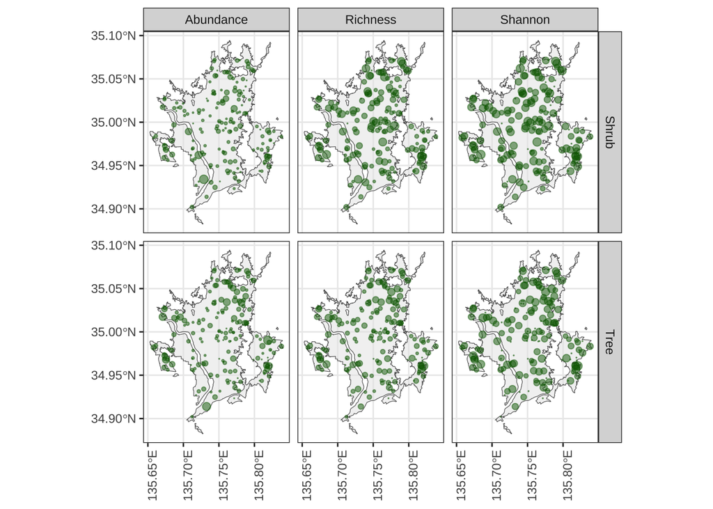

各生物多样性指标的数值分布如下所示：可见abundance和richness分布是比较偏态的，小数值很多。

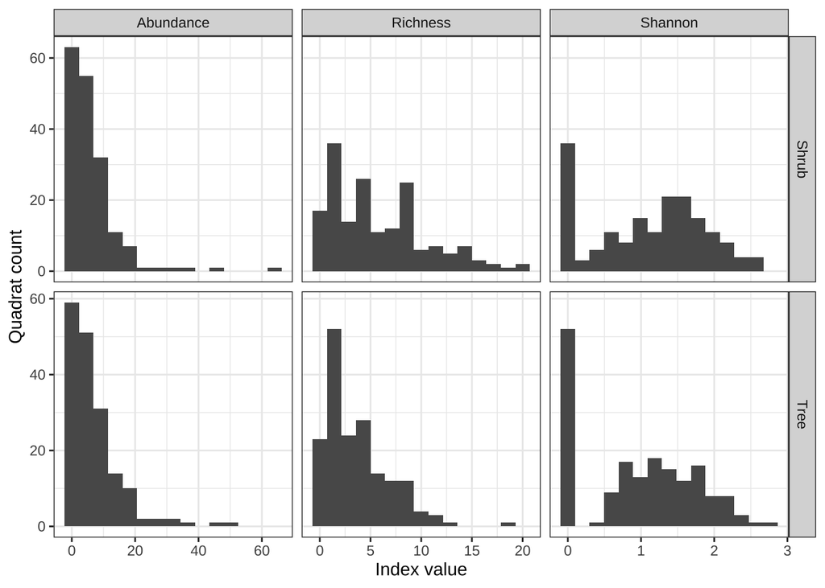

植物类别的细节：乔木和灌木所涉及的物种和科属数量，以及物种最多的科如下。注意，生态调查中乔木和灌木的区分方式是外形，主要是高度和是否有主干，因此两者可能有重叠；也就是说，一个物种如果长成灌木模样就会被分入灌木，但是在另外一个样地长成乔木，则会被分为乔木。

```
## Number of species:  133
##  Number of genera:  96
##  Number of family:  50# A tibble: 5 × 2
##   family           n
##   <chr>        <int>
## 1 Rosaceae        17
## 2 Oleaceae        11
## 3 Cupressaceae     6
## 4 Fagaceae         5
## 5 Magnoliaceae     5
```

```
## Number of species:  198
##  Number of genera:  144
##  Number of family:  74# A tibble: 5 × 2
##   family           n
##   <chr>        <int>
## 1 Rosaceae        21
## 2 Oleaceae        12
## 3 Cupressaceae     7
## 4 Ericaceae        7
## 5 Lamiaceae        6
```

自变量包括3组：土地利用，为各个样地中各类土地利用的占比；人口变量，为各个样地中不同年龄段人口占比；地价。下面先展示各个自变量的数值分布。

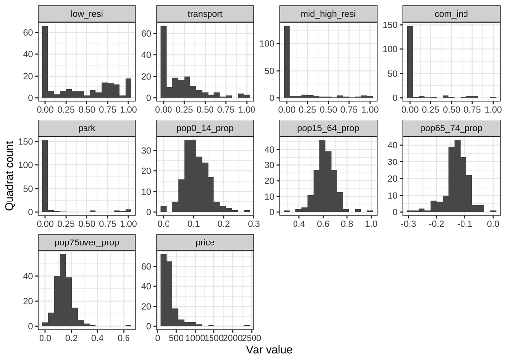

然后是一些描述性统计：尽管由于一些自变量非正态分布，所以以中位数来描述其总体情况更合适，但是此处仍然提供中位数和平均值，以方便参考。

| var | median | mean |
| --- | --- | --- |
| low_resi | 0.3099173 | 0.3892217 |
| transport | 0.1543439 | 0.2056859 |
| mid_high_resi | 0.0000000 | 0.1148917 |
| com_ind | 0.0000000 | 0.0753214 |
| park | 0.0000000 | 0.0741936 |
| pop0_14_prop | 0.1063039 | 0.1089962 |
| pop15_64_prop | 0.6147689 | 0.6151091 |
| pop65_74_prop | -0.1299056 | -0.1303256 |
| pop75over_prop | 0.1424345 | 0.1455691 |
| price | 254.8267992 | 339.0183134 |

## **相关分析**

之前的分析直接采用了皮尔森相关分析，那是错误的，因为应该根据数值是否符合正态分布来选择相关分析方法。采用Shapiro-Wilk检验方法对各个生物多样性指数数值的正态性进行检验，发现没有任何一个指数符合正态分布；结合上面的数值分布图，我们发现大部分数值是偏态的。因此不能用皮尔森相关分析，而应该用斯皮尔曼相关分析。

```
## # A tibble: 6 × 3
##   var             shapiro_p p_sig
##   <chr>               <dbl> <lgl>
## 1 tree_richness    2.23e- 9 TRUE
## 2 tree_abundance   3.82e-15 TRUE
## 3 tree_shannon     8.20e- 9 TRUE
## 4 shrub_richness   1.07e- 7 TRUE
## 5 shrub_abundance  5.32e-18 TRUE
## 6 shrub_shannon    4.14e- 7 TRUE
```

从下面的相关图可以看出，一方面，直接有相关性的变量对很少；另一方面，在有相关性的变量对中，各个解释变量对各响应变量的效应比较一致。例如，底层居住用地比例（low_resi）对灌木richness、Shannon都是正相关，也就是说在不考虑其他解释变量的情况下，样地中居住用地比例越大，灌木richness、Shannon就越高；商业工业用地（com_ind）对乔木的三个多样性指数和灌木richness呈现负相关；而park主要对乔木richness和abundance显著正相关，这也很容易解释，因为公园里种的植物通常比较多，所以abundance高，但是种类不一定均匀，因此shannon不一定高。pop15_64_prop和乔木各项指标呈负相关；pop_65_74_prop和乔木richness和shannon呈负相关。

关于作图：可以给我提具体的颜色和样式要求。

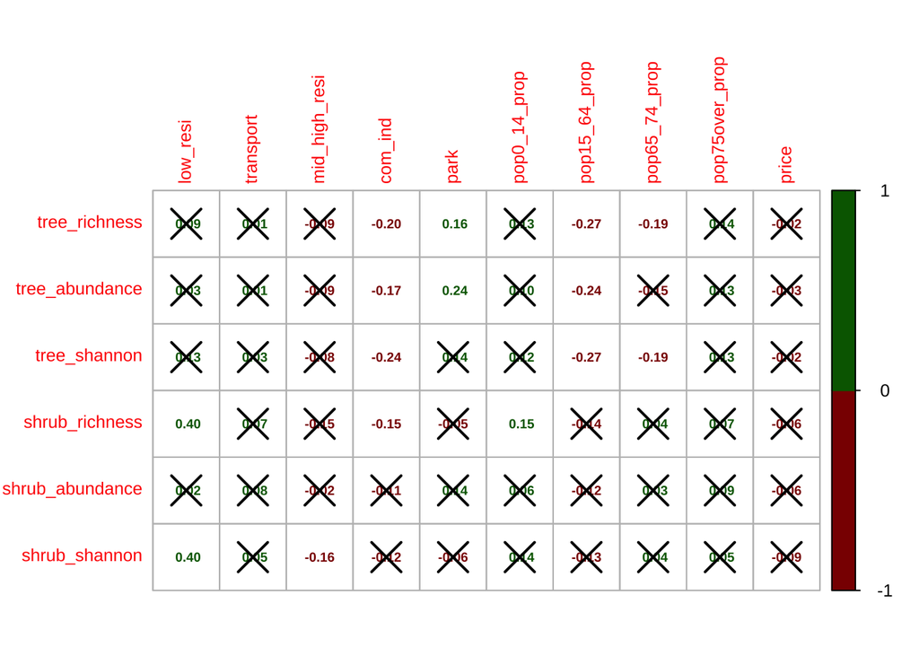

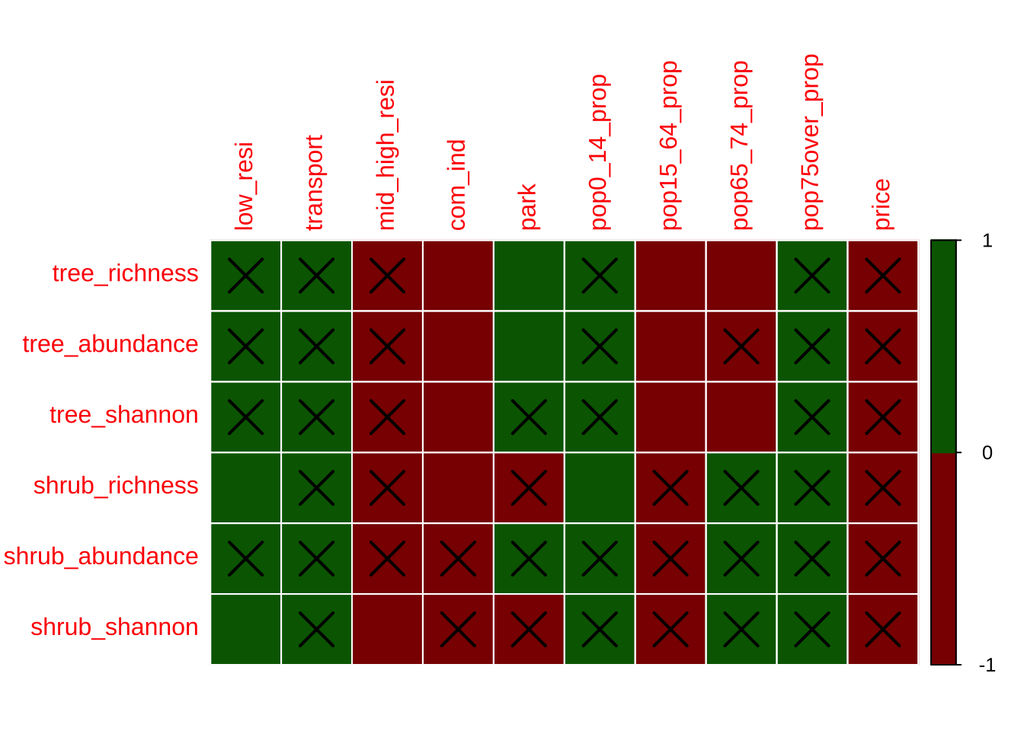

## GLM

原本的分析：将各种组合的变量扔进模型，然后筛选出一个"最佳模型"。然而实际上我们的变量并不多，因此没有必要使用这种方法，另一方面是当时筛选出的最佳模型结果混杂，且效果提升不佳。基于这些考虑，本次分析改进了分析思路：对于每个生物多样性指数 vs. 三组自变量，直接构建3个模型：仅包含土地利用变量的模型；仅包含人口变量的模型；包含土地利用变量、人口变量、土地价格的模型。然后对比各个模型中每个自变量的表现，来判断自变量和生物多样性指数的关系，以及这种关系是否稳健。

表格结果如下：

| exp_var | tree_richness-1 | tree_richness-2 | tree_richness-3 | tree_abundance-1 | tree_abundance-2 | tree_abundance-3 | tree_shannon-1 | tree_shannon-2 | tree_shannon-3 | shrub_richness-1 | shrub_richness-2 | shrub_richness-3 | shrub_abundance-1 | shrub_abundance-2 | shrub_abundance-3 | shrub_shannon-1 | shrub_shannon-2 | shrub_shannon-3 |
| --- | --- | --- | --- | --- | --- | --- | --- | --- | --- | --- | --- | --- | --- | --- | --- | --- | --- | --- |
| (Intercept) | 2.90*** | 1.58*** | 2.78*** | 3.90*** | 2.05*** | 3.31*** | 1.22 | 0.25 | 1.06 | 3.21*** | 1.36*** | 2.65*** | 4.78*** | 1.85*** | 4.36*** | 1.21 | -0.26 | 0.63 |
| pop0_14_prop | 2.51* |  | 2.11* | 0.17 |  | 1.27 | 2.10 |  | 1.72 | 2.39** |  | 1.41 | 1.47 |  | 2.40 | 1.95 |  | 1.32 |
| pop15_64_prop | -3.03*** |  | -2.17*** | -3.22*** |  | -2.15*** | -2.56** |  | -1.61 | -2.30*** |  | -1.89*** | -3.92** |  | -3.40* | -1.73* |  | -1.34 |
| pop65_74_prop | 0.25 |  | -0.80 | 0.12 |  | -1.21 | -0.34 |  | -1.47 | 2.30* |  | 2.35* | 5.58 |  | 4.94 | 2.04 |  | 1.92 |
| low_resi |  | -0.11 | -0.25 |  | -0.08 | -0.22* |  | -0.13 | -0.26 |  | 0.85*** | 0.83*** |  | -0.14 | -0.23 |  | 0.74*** | 0.73*** |
| transport |  | -0.41* | -0.49* |  | -0.38* | -0.47** |  | -0.49 | -0.57 |  | 0.28 | 0.29 |  | 0.15 | 0.07 |  | 0.18 | 0.19 |
| mid_high_resi |  | -0.67** | -0.75*** |  | -0.54*** | -0.64*** |  | -0.57 | -0.67* |  | -0.18 | -0.12 |  | -0.29 | -0.25 |  | -0.11 | -0.07 |
| com_ind |  | -1.25*** | -1.23*** |  | -0.21 | -0.14 |  | -1.91*** | -1.93*** |  | -0.32 | -0.22 |  | -0.44 | -0.31 |  | 0.01 | 0.09 |
| park |  | 0.02 | -0.10 |  | 0.77*** | 0.61*** |  | -7.40e-03 | -0.13 |  | 0.08 | 0.07 |  | 0.66 | 0.60 |  | 0.17 | 0.19 |
| price |  |  | -4.33e-04* |  |  | -5.10e-04*** |  |  | -4.19e-04 |  |  | 2.23e-05 |  |  | -7.75e-05 |  |  | 3.80e-05 |

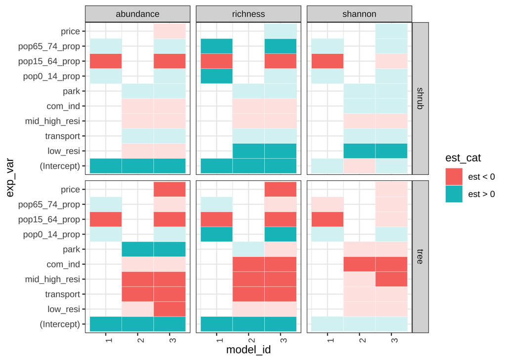